© Bản quyền thuộc về Quantopian Inc.  
© Bản quyền sửa đổi thuộc về AI Cafe¹  
Giấy phép [Creative Commons Attribution 4.0](https://creativecommons.org/licenses/by/4.0/legalcode).  
[Khuyến cáo](https://aicafe.one/khuyen-cao/)

# Mô Hình Tác Động Thị Trường (Market Impact Models)

By Dr. Michele Goe

Edited by AI Cafe¹

Trong bài giảng này, chúng tôi tìm cách làm rõ chi phí giao dịch và cách chúng ảnh hưởng đến hiệu suất của thuật toán. Đến cuối bài giảng này, bạn nên có khả năng:

1. Hiểu các thuộc tính ảnh hưởng đến chi phí giao dịch dựa trên nghiên cứu mô hình tác động thị trường đã công bố và kinh nghiệm của chính chúng tôi.
2. Hiểu tác động của tỷ lệ quay vòng, chi phí giao dịch và đòn bẩy đến hiệu suất chiến lược của bạn.
3. Làm quen với cách mà các đội giao dịch định lượng trong tổ chức suy nghĩ và đo lường chi phí giao dịch.

```python
import numpy as np
import matplotlib.pyplot as plt
import pandas as pd
```

## Giới thiệu về Chi phí Giao dịch

Chi phí giao dịch rơi vào hai loại

- Chi phí trực tiếp (hoa hồng và phí): rõ ràng, dễ đo lường và trong giao dịch tổ chức, tương đối "nhỏ"
- Chi phí gián tiếp (tác động thị trường và chi phí chênh lệch): **mục đích của bài giảng này**

Slippage là khi giá 'trượt' trước khi giao dịch được thực hiện hoàn toàn, dẫn đến giá thực hiện khác với giá tại thời điểm đặt lệnh. Các thuộc tính của một giao dịch mà nghiên cứu của chúng tôi cho thấy có ảnh hưởng lớn nhất đến slippage là:

1. **Biến động**
2. **Thanh khoản**
3. **Kích thước tương đối của lệnh**
4. **Chênh lệch giá mua - bán**

## Tác động của Chi phí Giao dịch đến Hiệu suất Danh mục Đầu tư

Hãy xem xét một danh mục đầu tư giả định về chênh lệch thống kê tần suất trung bình. (Chiến lược tần suất trung bình thường đề cập đến một mức quay vòng hàng ngày từ $0.05$ - $0.67$. Điều này đại diện cho một khoảng thời gian nắm giữ từ một ngày đến một tuần. Chênh lệch thống kê đề cập đến việc sử dụng các thuật toán tính toán để mua và bán cổ phiếu đồng thời theo một mô hình thống kê.)

| Thuộc tính Thuật toán | Số lượng |
| --- | --- |
| Thời gian nắm giữ (tuần) | 1 |
| Tỷ lệ đòn bẩy | 2 |
| Tài sản quản lý (tỷ) | 100 |
| Số ngày giao dịch mỗi năm | 252 |
| Tỷ lệ tài sản quản lý giao dịch mỗi ngày | 0.4 |

Điều này có nghĩa là chúng tôi giao dịch vào và ra khỏi một danh mục đầu tư mới khoảng 50 lần mỗi năm. Với tỷ lệ đòn bẩy 2 lần, trên 100 tỷ trong tài sản quản lý, chúng tôi giao dịch 20 nghìn tỷ mỗi năm.

**Q: Đối với mức độ quay vòng này, tác động của 1 bps chi phí thực hiện đến lợi nhuận của quỹ là gì?**

Điều này có nghĩa là đối với mỗi điểm cơ bản ($0.01\%$) của chi phí giao dịch, chúng tôi mất $2\%$ hiệu suất của thuật toán.

```python
def perf_impact(leverage, turnover , trading_days, txn_cost_bps):
    p = leverage *  turnover * trading_days * txn_cost_bps/10000.
    return p
```

```python
print(perf_impact(leverage=2, turnover=0.4, trading_days=252, txn_cost_bps=1))
```

```
0.02016
```

## Các đội giao dịch định lượng trong tổ chức đánh giá chi phí giao dịch như thế nào?

Các đội giao dịch định lượng trong tổ chức thường sử dụng các chiến thuật thực hiện nhằm hoàn thành các đơn hàng chính một cách trọn vẹn, đồng thời giảm thiểu chi phí thực hiện. Để đạt được mục tiêu này, các đơn hàng chính thường được chia thành nhiều đơn hàng con, được định tuyến đến các địa điểm thực hiện khác nhau, với mục tiêu là nắm bắt tất cả thanh khoản có sẵn và giảm thiểu chênh lệch giá mua-bán. Giá thực hiện ở cấp độ tổng thể có thể được biểu diễn dưới dạng giá trung bình trọng số theo khối lượng của tất cả các đơn hàng con.

**Hỏi: Chúng ta nên so sánh giá thực hiện của mình với những tiêu chí nào?**

*Các tiêu chí ví dụ:*

- **Giá đến** - giá "quyết định" của thuật toán, được định nghĩa là giá giữa tại thời điểm thuật toán đặt đơn hàng chính (giá giữa là điểm giữa giữa giá mua và giá bán tốt nhất)
- **VWAP theo khoảng thời gian** - giá trung bình trọng số theo khối lượng trong suốt thời gian tồn tại của đơn hàng
- **T + 10 phút** - tiêu chí hồi phục, giá 10 phút sau khi thực hiện lần cuối so với giá thực hiện
- **T + 30 phút** - tiêu chí hồi phục, giá 30 phút sau khi thực hiện lần cuối so với giá thực hiện
- **Đóng cửa** - tiêu chí hồi phục, giá tại thời điểm đóng cửa so với giá thực hiện
- **Mở cửa** - tiêu chí động lực, giá tại thời điểm mở cửa so với giá thực hiện
- **Đóng cửa trước đó** - tiêu chí động lực, giá tại đóng cửa trước đó so với giá thực hiện *Các chỉ số và định nghĩa khác*

$$ Chỉ số = \frac{Bên\thinspace * (Tiêu\thinspace chí - Giá\thinspace thực\thinspace hiện )* 100 * 100}{ Tiêu\thinspace chí }$$

*Ý tưởng chính*

- **Giá thực hiện** - giá trung bình trọng số theo khối lượng của tất cả các lần thực hiện hoặc các đơn hàng con
- **Chi phí so với giá đến** - sự khác biệt giữa giá đến và giá thực hiện, được biểu thị bằng điểm cơ sở. Ý tưởng với tiêu chí này là so sánh giá thực hiện với giá quyết định của chiến lược. Chi phí này đôi khi được gọi là "trượt giá" hoặc "thiếu hụt thực hiện."

Các chỉ số hồi phục cho chúng ta một dấu hiệu về tác động tạm thời của chúng ta sau khi đơn hàng được thực hiện. Thông thường, chúng ta mong đợi giá cổ phiếu sẽ hồi phục một chút, sau khi hoàn thành đơn hàng của chúng ta, khi sự đóng góp của chúng ta vào sự mất cân bằng mua-bán được phản ánh trên thị trường. Các chỉ số động lực cho chúng ta biết hướng đi của sự trôi giá trước khi thực hiện. Thường thì, giao dịch với động lực đáng kể có thể ảnh hưởng đến khả năng của chúng ta trong việc giảm thiểu chi phí chênh lệch giá mua-bán.

Khi thực hiện một đơn hàng, một trong những sự đánh đổi chính cần xem xét là rủi ro về thời gian so với tác động thị trường:

- **Rủi ro về thời gian** - rủi ro của sự trôi giá và rò rỉ thông tin khi khoảng cách giữa giá giữa đến và lần thực hiện cuối cùng tăng lên.
- **Tác động thị trường** - (cấp bách cao) rủi ro làm thay đổi thị trường bằng cách rút ngắn khoảng thời gian giữa giá giữa đến và lần thực hiện cuối cùng.

Trong khuôn khổ này, sự cấp bách trung lập của việc thực hiện xảy ra tại giao điểm của rủi ro thị trường và tác động thị trường - trong trường hợp này, mỗi yếu tố đều đóng góp như nhau vào chi phí thực hiện.

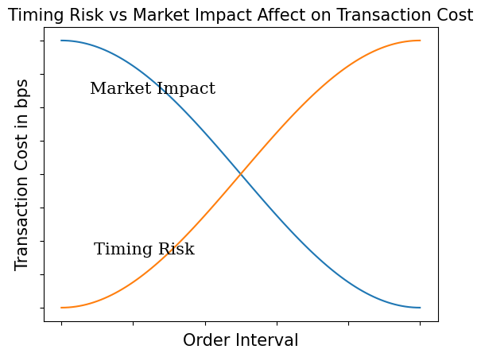

```python
x = np.linspace(0,1,101)
risk = np.cos(x*np.pi)
impact = np.cos(x* np.pi+ np.pi)

fig,ax = plt.subplots(1)
# Make your plot, set your axes labels
ax.plot(x,risk)
ax.plot(x,impact)
ax.set_ylabel('Transaction Cost in bps', fontsize=15)
ax.set_xlabel('Order Interval', fontsize=15)
ax.set_yticklabels([])
ax.set_xticklabels([])
ax.grid(False)
ax.text(0.09, -0.6, 'Timing Risk', fontsize=15, fontname="serif")
ax.text(0.08, 0.6, 'Market Impact', fontsize=15, fontname="serif")
plt.title('Timing Risk vs Market Impact Affect on Transaction Cost', fontsize=15)
plt.show()
```

## **Tính thanh khoản**

Tính thanh khoản có thể được nhìn nhận từ nhiều góc độ khác nhau. Trong bối cảnh quản lý thực thi, chúng ta có thể coi nó là hoạt động, được đo bằng số lượng cổ phiếu và tiền được giao dịch, cũng như tần suất và kích thước của các giao dịch được thực hiện trên thị trường. "Tính thanh khoản tốt" cũng được đạt được thông qua một số lượng đa dạng các nhà tham gia thị trường ở cả hai phía của thị trường.

Đánh giá tính thanh khoản bằng:

- đường cong khối lượng trong ngày
- phần trăm khối lượng của ngày
- phần trăm lượng tiền trung bình hàng ngày trong một khoảng thời gian
- đường cong khối lượng tích lũy trong ngày
- kích thước đơn hàng tương đối

Nói chung, tính thanh khoản cao nhất khi chúng ta gần đến giờ đóng cửa, và cao thứ hai vào lúc mở cửa. Giữa ngày có tính thanh khoản thấp nhất. Tính thanh khoản cũng nên được xem xét tương đối với kích thước đơn hàng của bạn và các chứng khoán khác trong cùng một lĩnh vực và loại.

*Chú ý: dữ liệu theo phút được lấy từ CSDL của AI Cafe¹, chúng tôi không public dữ liệu này, khi chạy lại notebook các bạn có thể bỏ qua những cell dưới đây*

```python
!curl -fsSLO https://raw.githubusercontent.com/algo-stocks/data/master/data/robusta.py
%run -i robusta.py
```

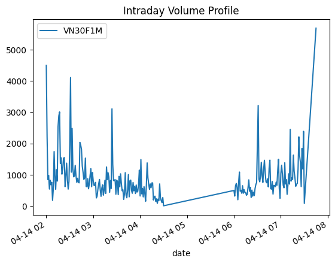

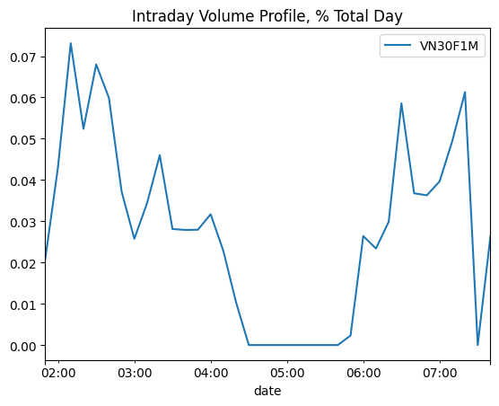

```python
from data import get_prices

dat = get_prices('VN30F1M', frequency='minute', field='volume', start_date='2025-01-01', end_date='2025-04-23').fillna(0)

dat['2025-04-14':'2025-04-14'].plot(title='Intraday Volume Profile') # intraday volume profile plot
(dat['2025-04-14':'2025-04-14'].resample('10min', closed='right').sum()/\
     dat['2025-04-14':'2025-04-14'].sum()).plot(); # percent volume plot
plt.title('Intraday Volume Profile, % Total Day');
```

```python
df = pd.DataFrame(dat)

df.columns = ['interval_vlm']

df_daysum = df.resample('d').sum() # take sum of each day
df_daysum.columns = ['day_vlm']
df_daysum['day'] = df_daysum.index.date # add date index as column

df['min_of_day']=(df.index.hour-2)*60 + df.index.minute # calculate minutes from open
df['time']=df.index.time # add time index as column

conversion = {'interval_vlm':'sum', 'min_of_day':'last', 'time':'last'}
df = df.resample('10min', closed='right').apply(conversion) # apply conversions to columns at 10 min intervals
df['day'] = df.index.date

df = df.merge(df_daysum, how='left', on='day') # merge df and df_daysum dataframes
df['interval_pct'] = df['interval_vlm'] / df['day_vlm'] # calculate percent of days volume for each row
df.head()
```

|  | interval_vlm | min_of_day | time | day | day_vlm | interval_pct |
| --- | --- | --- | --- | --- | --- | --- |
| 0 | 1745 | 10.0 | 02:10:00 | 2025-01-02 | 153113 | 0.011397 |
| 1 | 2210 | 20.0 | 02:20:00 | 2025-01-02 | 153113 | 0.014434 |
| 2 | 1271 | 30.0 | 02:30:00 | 2025-01-02 | 153113 | 0.008301 |
| 3 | 9109 | 40.0 | 02:40:00 | 2025-01-02 | 153113 | 0.059492 |
| 4 | 8100 | 50.0 | 02:50:00 | 2025-01-02 | 153113 | 0.052902 |

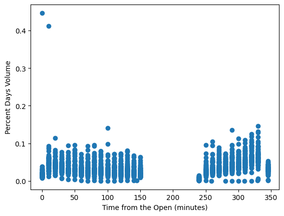

```python
plt.scatter(df.min_of_day, df.interval_pct)
plt.xlabel('Time from the Open (minutes)')
plt.ylabel('Percent Days Volume')
```

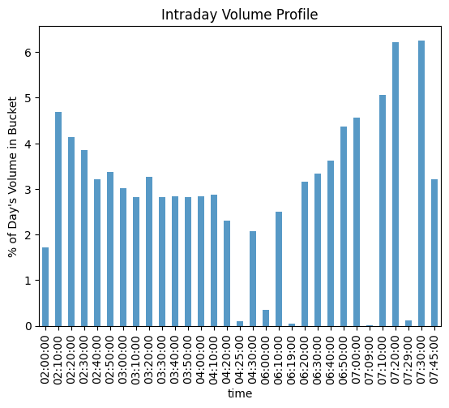

```python
grouped = df.groupby(df.time) # group by 10 minute interval times
y = grouped.interval_pct.median()  # get median values of groupby
x = y.index

ax1 = (100*y).plot(kind='bar', alpha=0.75) # plot percent daily volume grouped by 10 minute interval times
plt.title('Intraday Volume Profile');
ax1.set_ylabel('% of Day\'s Volume in Bucket');
```

## Kích thước Tương đối của Đơn hàng

Nếu chúng ta nhận thấy thuật toán của mình có kích thước tương đối của đơn hàng cao, thì có thể chúng ta muốn chuyển sang một chiến lược thực hiện quản lý thanh khoản khi giao dịch để đảm bảo hoàn thành đơn hàng trước cuối ngày. Các chiến lược thực hiện quản lý thanh khoản có các ràng buộc cụ thể về tính cấp bách của việc thực hiện, lựa chọn địa điểm thực hiện và việc nắm bắt chênh lệch mua bán với mục tiêu hoàn thành đơn hàng. Quay lại với các đường cong rủi ro của chúng ta, chúng ta mong đợi chi phí giao dịch cao hơn khi giao dịch lâu hơn. Do đó, tỷ lệ phần trăm ADV của một đơn hàng càng cao thì chi phí giao dịch càng đắt đỏ hơn.

```python
dat = get_prices('VN30F1M', frequency='minute', field='volume', start_date='2023-01-01', end_date='2025-01-01').fillna(0)
```

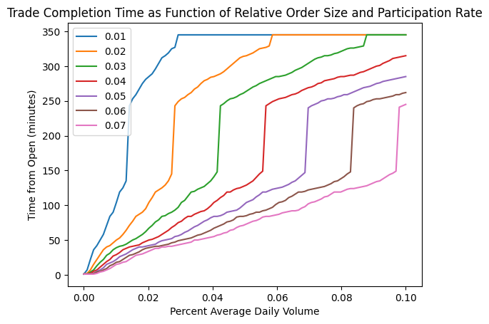

```python
day = dat['2023-01-03':'2023-01-03']

def relative_order_size(participation_rate, pct_ADV):
    fill_start = day.index[0] # start order at 9:31
    ADV20 = dat.resample("1d").sum()[-20:].mean().iloc[0] # calculate 20 day ADV
    order_size = int(pct_ADV * ADV20)

    try :
        ftime = day[(order_size * 1.0 / participation_rate)<=day.cumsum().values].index[0]
    except:
        ftime = day.index[-1] # set fill time to 4p
    fill_time = max(1,int((ftime - fill_start).total_seconds()/60.0))
    return fill_time

def create_plots(participation_rate, ax):
    df_pr = pd.DataFrame(data=np.linspace(0.0,0.1,100), columns = ['adv'] ) # create dataframe with intervals of ADV
    df_pr['pr'] = participation_rate # add participation rate column

    df_pr['fill_time'] = df_pr.apply(lambda row: relative_order_size(row['pr'],row['adv']), axis = 1) # get fill time

    ax.plot(df_pr['adv'],df_pr['fill_time'], label=participation_rate) # generate plot line with ADV and fill time

fig, ax = plt.subplots()
for i in [0.01,0.02,0.03,0.04,0.05,0.06,0.07]: # for participation rate values
    create_plots(i,ax) # generate plot line

plt.ylabel('Time from Open (minutes)')
plt.xlabel('Percent Average Daily Volume')
plt.title('Trade Completion Time as Function of Relative Order Size and Participation Rate')
ax.legend();
```

## Biến động

Biến động là một chỉ số thống kê đo lường sự phân tán của lợi nhuận cho một chứng khoán, được tính toán như độ lệch chuẩn của lợi nhuận. Càng nhiều biến động thì càng nhiều sự không chắc chắn trong lợi nhuận. Riêng với thị trường Việt Nam, chúng ta thấy thị trường biến động mạnh vào phiên giao dịch buổi chiều, trước khi đóng cửa thị trường.

Chúng tôi sử dụng hai phương pháp để tính toán biến động cho mục đích minh họa, OHLC và phương pháp phổ biến nhất, từ đóng cửa đến đóng cửa. OHLC sử dụng ước lượng biến động Garman-Klass Yang-Zhang, sử dụng dữ liệu mở, cao, thấp và đóng.

PHƯƠNG PHÁP ƯỚC LƯỢNG BIẾN ĐỘNG OHLC

$$\sigma^2 = \frac{Z}{n} \sum \left[\left(\ln \frac{O_i}{C_{i-1}} \right)^2 + \frac{1}{2} \left( \ln \frac{H_i}{L_i} \right)^2 - (2 \ln 2 -1) \left( \ln \frac{C_i}{O_i} \right)^2 \right]$$

PHƯƠNG PHÁP ƯỚC LƯỢNG BIẾN ĐỘNG LỊCH SỬ TỪ ĐÓNG CỬA ĐẾN ĐÓNG CỬA

Biến động được tính là độ lệch chuẩn hàng năm của lợi nhuận log như chi tiết trong phương trình dưới đây.

$$ Lợi \thinspace nhuận = x_1 = \ln (\frac{c_i + d_i}{c_i-1} ) $$ trong đó $d_i$ = cổ tức thông thường (không điều chỉnh) và $c_i$ là giá đóng cửa $$ Biến \thinspace động = \sigma_x \sqrt{ \frac{1}{N} \sum_{i=1}^{N} (x_i - \bar{x})^2 }$$

```python
from data import get_pricing
df = get_pricing('VN30F1M', frequency='minute', start_date='2024-01-01', end_date='2024-07-01').fillna(0)
df.head()
```

| date | open | high | low | close | volume |
| --- | --- | --- | --- | --- | --- |
| 2024-01-02 02:00:00 | 1138.5 | 1139.7 | 1138.5 | 1139.3 | 3551 |
| 2024-01-02 02:01:00 | 1138.8 | 1139.6 | 1138.8 | 1139.4 | 1154 |
| 2024-01-02 02:02:00 | 1139.3 | 1139.5 | 1139.2 | 1139.3 | 625 |
| 2024-01-02 02:03:00 | 1139.3 | 1139.3 | 1138.9 | 1138.9 | 554 |
| 2024-01-02 02:04:00 | 1138.9 | 1139.0 | 1138.8 | 1138.9 | 322 |

```python
def gkyz_var(open, high, low, close, close_tm1): # Garman Klass Yang Zhang extension OHLC volatility estimate
    return np.log(open/close_tm1)**2 + 0.5*(np.log(high/low)**2) \
        - (2*np.log(2)-1)*(np.log(close/open)**2)

def historical_vol(close_ret, mean_ret): # close to close volatility estimate
    return np.sqrt(np.sum((close_ret-mean_ret)**2)/390)
```

```python
df['min_of_day'] = (df.index.hour-2)*60 + df.index.minute # calculate minute from the open
df['time'] = df.index.time # add column time index
df['day'] = df.index.date # add column date index
df.head()
```

| date | open | high | low | close | volume | min_of_day | time | day |
| --- | --- | --- | --- | --- | --- | --- | --- | --- |
| 2024-01-02 02:00:00 | 1138.5 | 1139.7 | 1138.5 | 1139.3 | 3551 | 0 | 02:00:00 | 2024-01-02 |
| 2024-01-02 02:01:00 | 1138.8 | 1139.6 | 1138.8 | 1139.4 | 1154 | 1 | 02:01:00 | 2024-01-02 |
| 2024-01-02 02:02:00 | 1139.3 | 1139.5 | 1139.2 | 1139.3 | 625 | 2 | 02:02:00 | 2024-01-02 |
| 2024-01-02 02:03:00 | 1139.3 | 1139.3 | 1138.9 | 1138.9 | 554 | 3 | 02:03:00 | 2024-01-02 |
| 2024-01-02 02:04:00 | 1138.9 | 1139.0 | 1138.8 | 1138.9 | 322 | 4 | 02:04:00 | 2024-01-02 |

```python
df['close_tm1'] = df.groupby('day')['close'].shift(1)  # shift close value down one row
df.close_tm1 = df.close_tm1.fillna(df.open)
df['min_close_ret'] = np.log( df['close'] /df['close_tm1']) # log of close to close
close_returns = df.groupby('day')['min_close_ret'].mean() # daily mean of log of close to close
new_df = df.merge(pd.DataFrame(close_returns), left_on ='day', right_index = True)
# handle when index goes from 16:00 to 9:31:

new_df['variance'] = new_df.apply(
    lambda row: historical_vol(row.min_close_ret_x, row.min_close_ret_y),
    axis=1)

new_df.head()
```

| date | open | high | low | close | volume | min_of_day | time | day | close_tm1 | min_close_ret_x | min_close_ret_y | variance |
| --- | --- | --- | --- | --- | --- | --- | --- | --- | --- | --- | --- | --- |
| 2024-01-02 02:00:00 | 1138.5 | 1139.7 | 1138.5 | 1139.3 | 3551 | 0 | 02:00:00 | 2024-01-02 | 1138.5 | 0.000702 | -0.000018 | 3.648622e-05 |
| 2024-01-02 02:01:00 | 1138.8 | 1139.6 | 1138.8 | 1139.4 | 1154 | 1 | 02:01:00 | 2024-01-02 | 1139.3 | 0.000088 | -0.000018 | 5.361552e-06 |
| 2024-01-02 02:02:00 | 1139.3 | 1139.5 | 1139.2 | 1139.3 | 625 | 2 | 02:02:00 | 2024-01-02 | 1139.4 | -0.000088 | -0.000018 | 3.527195e-06 |
| 2024-01-02 02:03:00 | 1139.3 | 1139.3 | 1138.9 | 1138.9 | 554 | 3 | 02:03:00 | 2024-01-02 | 1139.3 | -0.000351 | -0.000018 | 1.686422e-05 |
| 2024-01-02 02:04:00 | 1138.9 | 1139.0 | 1138.8 | 1138.9 | 322 | 4 | 02:04:00 | 2024-01-02 | 1138.9 | 0.000000 | -0.000018 | 9.171784e-07 |

```python
df_daysum = pd.DataFrame(new_df['variance'].resample('d').sum()) # get sum of intraday variances daily
df_daysum.columns = ['day_variance']
df_daysum['day'] = df_daysum.index.date
df_daysum.head()
```

| date | day_variance | day |
| --- | --- | --- |
| 2024-01-02 | 0.003385 | 2024-01-02 |
| 2024-01-03 | 0.003431 | 2024-01-03 |
| 2024-01-04 | 0.005318 | 2024-01-04 |
| 2024-01-05 | 0.004413 | 2024-01-05 |
| 2024-01-06 | 0.000000 | 2024-01-06 |

```python
conversion = {'variance':'sum', 'min_of_day':'last', 'time':'last'}
df = new_df.resample('10min', closed='right').apply(conversion)
df['day'] = df.index.date
df['time'] = df.index.time
df.head()
```

| date | variance | min_of_day | time | day |
| --- | --- | --- | --- | --- |
| 2024-01-02 01:50:00 | 0.000036 | 0.0 | 01:50:00 | 2024-01-02 |
| 2024-01-02 02:00:00 | 0.000080 | 10.0 | 02:00:00 | 2024-01-02 |
| 2024-01-02 02:10:00 | 0.000139 | 20.0 | 02:10:00 | 2024-01-02 |
| 2024-01-02 02:20:00 | 0.000087 | 30.0 | 02:20:00 | 2024-01-02 |
| 2024-01-02 02:30:00 | 0.000064 | 40.0 | 02:30:00 | 2024-01-02 |

```python
df = df.merge(df_daysum, how='left', on='day') # merge daily and intraday volatilty dataframes
df['interval_pct'] = df['variance'] / df['day_variance'] # calculate percent of days volatility for each row
df.head()
```

|  | variance | min_of_day | time | day | day_variance | interval_pct |
| --- | --- | --- | --- | --- | --- | --- |
| 0 | 0.000036 | 0.0 | 01:50:00 | 2024-01-02 | 0.003385 | 0.010779 |
| 1 | 0.000080 | 10.0 | 02:00:00 | 2024-01-02 | 0.003385 | 0.023640 |
| 2 | 0.000139 | 20.0 | 02:10:00 | 2024-01-02 | 0.003385 | 0.040971 |
| 3 | 0.000087 | 30.0 | 02:20:00 | 2024-01-02 | 0.003385 | 0.025694 |
| 4 | 0.000064 | 40.0 | 02:30:00 | 2024-01-02 | 0.003385 | 0.018919 |

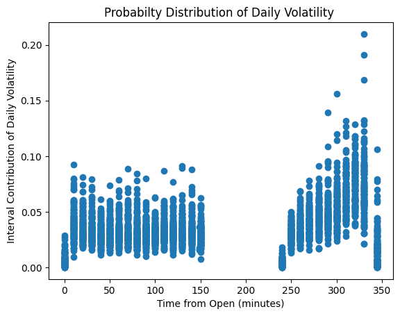

```python
plt.scatter(df.min_of_day, df.interval_pct)
plt.xlabel('Time from Open (minutes)')
plt.ylabel('Interval Contribution of Daily Volatility')
plt.title('Probabilty Distribution of Daily Volatility ')
```

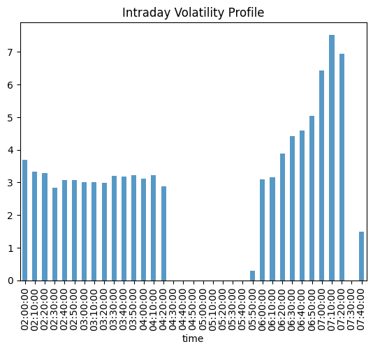

```python
import datetime
grouped = df.groupby(df.time) # groupby time
y = grouped.interval_pct.median() # get median
y = y[datetime.time(2,0):datetime.time(7,45)]

(100*y).plot(kind='bar', alpha=0.75);# plot interval percent of median daily volatility
plt.title('Intraday Volatility Profile')
ax1.set_ylabel('% of Day\'s Variance in Bucket');
```

## Chênh lệch Giá Mua - Giá Bán

```python
def model_spread(time, vol, mcap = 1.67 * 10 ** 10, adv = 84.5, px = 91.0159):
    time_bins = np.array([0.0, 960.0, 2760.0, 5460.0, 21660.0]) #seconds from market open
    time_coefs = pd.Series([0.0, -0.289, -0.487, -0.685, -0.952])

    vol_bins = np.array([0.0, .1, .15, .2, .3, .4])
    vol_coefs = pd.Series([0.0, 0.251, 0.426, 0.542, 0.642, 0.812])

    mcap_bins = np.array([0.0, 2.0, 5.0, 10.0, 25.0, 50.0]) * 10 ** 9
    mcap_coefs = pd.Series([0.291, 0.305, 0.0, -0.161, -0.287, -0.499])

    adv_bins = np.array([0.0, 50.0, 100.0, 150.0, 250.0, 500.0]) * 10 ** 6
    adv_coefs = pd.Series([0.303, 0.0, -0.054, -0.109, -0.242, -0.454])

    px_bins = np.array([0.0, 28.0, 45.0, 62.0, 82.0, 132.0])
    px_coefs = pd.Series([-0.077, -0.187, -0.272, -0.186, 0.0, 0.380])

    return np.exp(1.736 +\
                  time_coefs[np.digitize(time, time_bins) - 1] +\
                  vol_coefs[np.digitize(vol, vol_bins) - 1] +\
                  mcap_coefs[np.digitize(mcap, mcap_bins) - 1] +\
                  adv_coefs[np.digitize(adv, adv_bins) - 1] +\
                  px_coefs[np.digitize(px, px_bins) - 1])
```

### Dự đoán độ chênh lệch cho đơn hàng sau:

- Cổ phiếu: DPS
- Số lượng: 425 cổ phiếu
- Thời gian trong ngày: 9:41 sáng ngày 19 tháng 7 năm 2017, 600 giây kể từ khi mở cửa
- Vốn hóa thị trường: 1.67e10
- Biến động: 18.8%
- ADV: 929k cổ phiếu; 84.5 triệu đô la
- Giá trung bình: 91.0159

```python
t = 10 * 60
vlty = 0.188
mcap = 1.67 * 10 ** 10
adv = 84.5 *10
price = 91.0159
print(model_spread(t, vlty, mcap, adv, price), 'bps')
```

```
10.014159084591371 bps
```

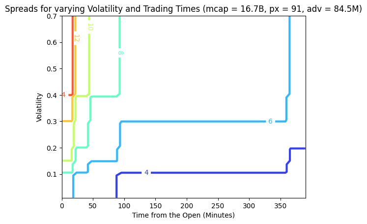

```python
x = np.linspace(0,390*60) # seconds from open shape (50,)
y = np.linspace(.01,.7) # volatility shape(50,)
mcap = 1.67 * 10 ** 10
adv = 84.5
px = 91.0159


vlty_coefs = pd.Series([0.0, 0.251, 0.426, 0.542, 0.642, 0.812])
vlty_bins = np.array([0.0, .1, .15, .2, .3, .4])
time_bins = np.array([0.0, 960.0, 2760.0, 5460.0, 21660.0]) #seconds from market open
time_coefs = pd.Series([0.0, -0.289, -0.487, -0.685, -0.952])
mcap_bins = np.array([0.0, 2.0, 5.0, 10.0, 25.0, 50.0]) * 10 ** 9
mcap_coefs = pd.Series([0.291, 0.305, 0.0, -0.161, -0.287, -0.499])
adv_bins = np.array([0.0, 50.0, 100.0, 150.0, 250.0, 500.0]) * 10 ** 6
adv_coefs = pd.Series([0.303, 0.0, -0.054, -0.109, -0.242, -0.454])
px_bins = np.array([0.0, 28.0, 45.0, 62.0, 82.0, 132.0])
px_coefs = pd.Series([-0.077, -0.187, -0.272, -0.186, 0.0, 0.380])
# shape (1, 50)
time_contrib = np.take(time_coefs.values, np.digitize(x, time_bins) - 1).reshape((1, len(x)))
# shape (50, 1)
vlty_contrib = np.take(vlty_coefs.values, np.digitize(y, vlty_bins) - 1).reshape((len(y), 1))
# scalar
mcap_contrib = mcap_coefs[np.digitize((mcap,), mcap_bins)[0] - 1]
# scalar
adv_contrib = adv_coefs[np.digitize((adv,), adv_bins)[0] - 1]
# scalar
px_contrib = px_coefs[np.digitize((px,), px_bins)[0] - 1]

z_scalar_contrib = 1.736 + mcap_contrib + adv_contrib + px_contrib


Z = np.exp(z_scalar_contrib + time_contrib + vlty_contrib)

cmap=plt.get_cmap('jet')
X, Y = np.meshgrid(x,y)
CS = plt.contour(X/60,Y,Z, linewidths=3, cmap=cmap, alpha=0.8);
plt.clabel(CS)
plt.xlabel('Time from the Open (Minutes)')
plt.ylabel('Volatility')
plt.title('Spreads for varying Volatility and Trading Times (mcap = 16.7B, px = 91, adv = 84.5M)')
plt.show()
```

## **Định lượng Tác động Thị trường**

Các mô hình Tác động Thị trường lý thuyết cố gắng ước lượng chi phí giao dịch của việc giao dịch bằng cách sử dụng các thuộc tính đơn hàng. Có nhiều mô hình tác động thị trường đã được công bố. Dưới đây là một số ví dụ:

1. Almgren et al 2005
2. Kissell et al. 2004

Các mô hình học thuật có khái niệm về tác động tạm thời và vĩnh viễn. **Tác động Tạm thời** ghi nhận tác động lên chi phí giao dịch do tính cấp bách hoặc tính quyết liệt của giao dịch. Trong khi **Tác động Vĩnh viễn** ước lượng liên quan đến thông tin hoặc alpha ngắn hạn trong một giao dịch.

### Mô hình Almgren et al. (2005)

Mô hình này giả định rằng đơn hàng ban đầu, X, được hoàn thành với một tỷ lệ giao dịch đồng nhất trong khoảng thời gian khối lượng T. Cụ thể, tỷ lệ giao dịch theo đơn vị khối lượng là v = X/T, và được giữ cố định cho đến khi giao dịch hoàn tất. Tỷ lệ cố định trong các đơn vị này tương đương với việc thực hiện VWAP trong suốt thời gian thực hiện.

Almgren et al. mô hình hóa hai thuật ngữ này như thế nào.

$$\text{tcost} = 0.5 \overbrace{\gamma \sigma \frac{X}{V}\left(\frac{\Theta}{V}\right)^{1/4}}^{\text{permanent}} + \overbrace{\eta \sigma \left| \frac{X}{VT} \right|^{3/5}}^{\text{temporary}} $$

Trong đó, $\gamma$ và $\eta$ là "hệ số ảnh hưởng thị trường toàn cầu" và được các tác giả ước lượng dựa trên một mẫu lớn các giao dịch của các tổ chức; $\sigma$ là độ biến động hàng ngày của cổ phiếu; $\Theta$ là tổng số cổ phiếu đang lưu hành của cổ phiếu; $X$ là số lượng cổ phiếu bạn muốn giao dịch (không có dấu hiệu); $T$ là độ rộng thời gian theo % của thời gian giao dịch mà bạn chia nhỏ giao dịch; và $V$ là khối lượng giao dịch trung bình hàng ngày ("ADV") tính bằng số cổ phiếu của cổ phiếu. Cách hiểu của $\frac{\Theta}{V}$ là nghịch đảo của "vòng quay" hàng ngày, tỉ lệ phần trăm giá trị của công ty được giao dịch mỗi ngày.

### Các Hạn Chế Tiềm Tàng

Lưu ý rằng các bài báo của Almgren và cộng sự (2005) và Kissell, Glantz và Malamut (2004) được phát hành trước khi áp dụng và triển khai từng bước của [**Reg NMS**](https://www.sec.gov/rules/final/34-51808.pdf), trước "cuộc khủng hoảng định lượng" vào tháng 8 năm 2007, trước khi cuộc khủng hoảng tài chính ảnh hưởng đến thị trường vào quý 4 năm 2008, và nhiều sự phát triển khác trong cấu trúc thị trường.

```python
def perm_impact(pct_adv, annual_vol_pct = 0.25, inv_turnover = 200):
    gamma = 0.314
    return 10000 * gamma * (annual_vol_pct / 16) * pct_adv * (inv_turnover)**0.25

def temp_impact(pct_adv, minutes, annual_vol_pct = 0.25, minutes_in_day = 60*6.5):
    eta = 0.142
    day_frac = minutes / minutes_in_day
    return 10000 * eta * (annual_vol_pct / 16) * abs(pct_adv/day_frac)**0.6

def tc_bps(pct_adv, minutes, annual_vol_pct = 0.25, inv_turnover = 200, minutes_in_day = 60*6.5):
    perm = perm_impact(pct_adv, annual_vol_pct=annual_vol_pct, inv_turnover=inv_turnover)
    temp = temp_impact(pct_adv, minutes, annual_vol_pct=annual_vol_pct, minutes_in_day=minutes_in_day)
    return 0.5 * perm + temp
```

Vậy nếu chúng ta giao dịch 10% của ADV của một cổ phiếu với độ biến động hàng ngày là 1.57% và chúng ta dự định thực hiện điều này trong nửa ngày, chúng ta sẽ mong đợi 8 bps chi phí tạm thời (TC) (đây là ước tính của Almgren về chi phí tác động tạm thời trong kịch bản này). Từ tài liệu, đây là một đoạn nhỏ của đầu ra ở các tốc độ giao dịch khác nhau:

| Biến số | IBM |
| --- | --- |
| Lưu chuyển nghịch đảo ($\Theta/V$) | 263 |
| Độ biến động hàng ngày ($\sigma$) | 1.57% |
| Tỉ lệ giao dịch % ADV (X/V) | 10% |

| Mục | Nhanh | Trung bình | Chậm |
| --- | --- | --- | --- |
| Tác động vĩnh viễn (bps) | 20 | 20 | 20 |
| Thời gian giao dịch (phần trăm ngày) | 10% | 20% | 50% |
| Tác động tạm thời (bps) | 22 | 15 | 8 |
| Tác động tổng (bps) | 32 | 25 | 18 |

```python
print('Cost to trade Fast (First 40 mins):', round(tc_bps(pct_adv=0.1, annual_vol_pct=16*0.0157, inv_turnover=263, minutes=0.1*60*6.5),2), 'bps')
print('Cost to trade Medium (First 90 mins):', round(tc_bps(pct_adv=0.1, annual_vol_pct=16*0.0157, inv_turnover=263, minutes=0.2*60*6.5),2), 'bps' )
print('Cost to trade Slow by Noon:', round(tc_bps(pct_adv=0.1, annual_vol_pct=16*0.0157, inv_turnover=263, minutes=0.5*60*6.5),2), 'bps')
```

```
Cost to trade Fast (First 40 mins): 32.22 bps
Cost to trade Medium (First 90 mins): 24.63 bps
Cost to trade Slow by Noon: 18.41 bps
```

```python
print(round(tc_bps(pct_adv=0.005, minutes=30, annual_vol_pct=16*0.0157),2))
```

```
4.79
```

Giả sử chúng ta muốn giao dịch 2 triệu đô la giá trị danh nghĩa của Facebook và chúng ta sẽ gửi lệnh giao dịch đến một thuật toán thực hiện (ví dụ, VWAP) để được chia nhỏ trong vòng 15 phút.

```python
trade_notional = 2000000 # 2M notional
stock_price = 110.89 # dollars per share
shares_to_trade = trade_notional/stock_price
stock_adv_shares = 30e6 # 30 M
stock_shares_outstanding = 275e9/110.89

expected_tc = tc_bps(shares_to_trade/stock_adv_shares, minutes=15, annual_vol_pct=0.22)
print("Expected tc in bps: %0.2f" % expected_tc)
print("Expected tc in $ per share: %0.2f" % (expected_tc*stock_price / 10000))
```

```
Expected tc in bps: 1.66
Expected tc in $ per share: 0.02
```

Và để kích thích một chút trực giác, tổng chi phí dự kiến thay đổi theo tỷ lệ phần trăm ADV mà chúng ta muốn giao dịch trong 30 phút.

[figure not shown]

```python
x = np.linspace(0.0001,0.03)
plt.plot(x*100,tc_bps(x,30,0.25), label=r"$\sigma$ = 25%");
plt.plot(x*100,tc_bps(x,30,0.40), label=r"$\sigma$ = 40%");
plt.ylabel('tcost in bps')
plt.xlabel('Trade as % of ADV')
plt.title(r'tcost in Basis Points of Trade Value; $\sigma$ = 25% and 40%; time = 15 minutes');
plt.legend();
```

Hãy xem xét chi phí như một hàm của thời gian giao dịch và % ADV.

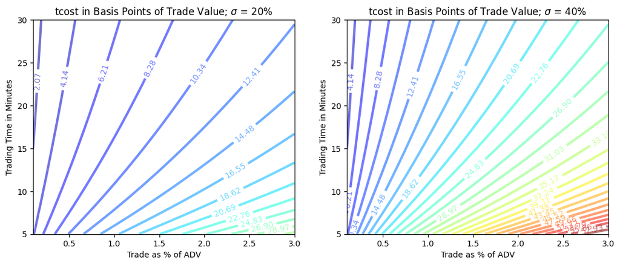

```python
x = np.linspace(0.001,0.03)
y = np.linspace(5,30)
X, Y = np.meshgrid(x,y)
Z = tc_bps(X,Y,0.20)
levels = np.linspace(0.0, 60, 30)
cmap=plt.get_cmap('Reds')
cmap=plt.get_cmap('hot')
cmap=plt.get_cmap('jet')

plt.rcParams["figure.figsize"] = (12.8,4.8)

plt.subplot(1,2,1);
CS = plt.contour(X*100, Y, Z, levels, linewidths=3, cmap=cmap, alpha=0.55);
plt.clabel(CS);
plt.ylabel('Trading Time in Minutes');
plt.xlabel('Trade as % of ADV');
plt.title(r'tcost in Basis Points of Trade Value; $\sigma$ = 20%');

plt.subplot(1,2,2);
Z = tc_bps(X,Y,0.40)
CS = plt.contour(X*100, Y, Z, levels, linewidths=3, cmap=cmap, alpha=0.55);
plt.clabel(CS);
plt.ylabel('Trading Time in Minutes');
plt.xlabel('Trade as % of ADV');
plt.title(r'tcost in Basis Points of Trade Value; $\sigma$ = 40%');
```

Ngoài ra, chúng ta có thể muốn có một vài trực giác về việc nếu chúng ta muốn giới hạn chi phí của mình, thì thời gian giao dịch sẽ thay đổi như thế nào so với tỷ lệ phần trăm của ADV.

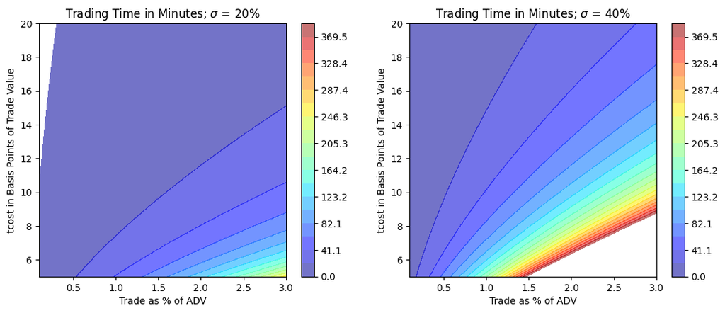

```python
x = np.linspace(0.001,0.03) # % ADV
y = np.linspace(1,60*6.5)   # time to trade
X, Y = np.meshgrid(x, y)

levels = np.linspace(0.0, 390, 20)
cmap=plt.get_cmap('Reds')
cmap=plt.get_cmap('hot')
cmap=plt.get_cmap('jet')

plt.subplot(1,2,1);

Z = tc_bps(X,Y,0.20)
plt.contourf(X*100, Z, Y, levels, cmap=cmap, alpha=0.55);
plt.title(r'Trading Time in Minutes; $\sigma$ = 20%');
plt.xlabel('Trade as % of ADV');
plt.ylabel('tcost in Basis Points of Trade Value');
plt.ylim(5,20)
plt.colorbar();

plt.subplot(1,2,2);
Z = tc_bps(X,Y,0.40)
plt.contourf(X*100, Z, Y, levels, cmap=cmap, alpha=0.55);
plt.title(r'Trading Time in Minutes; $\sigma$ = 40%');
plt.xlabel('Trade as % of ADV');
plt.ylabel('tcost in Basis Points of Trade Value');
plt.ylim(5,20);
plt.colorbar();
```

### Phân Tích: Chi phí Vĩnh Viễn và Tạm Thời

Đối với một cổ phiếu điển hình, hãy xem cách mà chi phí giao dịch (tcost) được phân chia thành chi phí vĩnh viễn và tạm thời.

[figure not shown]

```python
minutes = 30

x = np.linspace(0.0001,0.03)

f, (ax1, ax2) = plt.subplots(ncols=2, sharex=True, sharey=True)
f.subplots_adjust(hspace=0.15)

p = 0.5*perm_impact(x,0.20)
t = tc_bps(x,minutes,0.20)
ax1.fill_between(x*100, p, t, color='b', alpha=0.33);
ax1.fill_between(x*100, 0, p, color='k', alpha=0.66);
ax1.set_ylabel('tcost in bps')
ax1.set_xlabel('Trade as % of ADV')
ax1.set_title(r'tcost in bps of Trade Value; $\sigma$ = 20%; time = 15 minutes');

p = 0.5*perm_impact(x, 0.40)
t = tc_bps(x,minutes, 0.40)
ax2.fill_between(x*100, p, t, color='b', alpha=0.33);
ax2.fill_between(x*100, 0, p, color='k', alpha=0.66);

plt.xlabel('Trade as % of ADV')
plt.title(r'tcost in bps of Trade Value; $\sigma$ = 40%; time = 15 minutes');
```

### Mô hình Kissell et al (2004)

Mô hình này giả định rằng có một chi phí tác động tức thời lý thuyết $I^*$ mà nhà đầu tư phải chịu nếu tất cả cổ phiếu $Q$ được phát hành ra thị trường.

$$ MI_{bp} = b_1 I^* POV^{a_4} + (1-b_1)I^*$$

$$ I^* = a_1 \left(\frac{Q}{ADV}\right)^{a_2} \sigma^{a_3}$$

$$POV = \frac{Q}{Q+V}$$

- $I^*$ là tác động tức thời
- $POV$ là tỷ lệ phần trăm khối lượng giao dịch
- $V$ là khối lượng dự kiến trong khoảng thời gian giao dịch
- $b_1$ là tham số tác động tạm thời
- $ADV$ là khối lượng giao dịch trung bình hàng ngày trong 30 ngày
- $Q$ là kích thước đơn hàng

[output not shown]

```python
def kissell(adv, annual_vol, interval_vol, order_size):
    b1, a1, a2, a3, a4 = 0.9, 750., 0.2, 0.9, 0.5
    i_star = a1 * ((order_size/adv)**a2) * annual_vol**a3
    PoV = order_size/(order_size + adv)
    return b1 * i_star * PoV**a4 + (1 - b1) * i_star
```

```python
print(kissell(adv=5*10**6, annual_vol=0.2, interval_vol=adv * 0.06, order_size=0.01 * adv ), 'bps')
```

```
0.781932862914937 bps
```

[figure not shown]

```python
x = np.linspace(0.0001,0.1)
plt.plot(x,kissell(5*10**6,0.1, 2000*10**3, x*2000*10**3), label=r"$\sigma$ = 10%");
plt.plot(x,kissell(5*10**6,0.25, 2000*10**3, x*2000*10**3), label=r"$\sigma$ = 25%");
plt.ylabel('tcost in bps')
plt.xlabel('Trade as % of ADV')
plt.title(r'tcost in Basis Points of Trade Value; $\sigma$ = 25% and 40%; time = 15 minutes');
plt.legend();
```

## Kết luận

### Các thuộc tính đơn hàng sau đây dẫn đến tác động thị trường cao hơn:

- Kích thước đơn hàng tương đối lớn hơn
- Giao dịch các cổ phiếu không thanh khoản
- Giao dịch các cổ phiếu có khối lượng giao dịch hàng ngày thấp hơn (tính theo số cổ phiếu đang lưu hành)
- Thời gian giao dịch ngắn hơn
- Các cổ phiếu có độ biến động cao hơn
- Cần thiết hơn hoặc POV cao hơn
- Alpha ngắn hạn
- Giao dịch sớm hơn trong ngày
- Giao dịch các cổ phiếu có chênh lệch giá rộng hơn
- Giao dịch các cổ phiếu có ADV thấp hơn hoặc vào những ngày khối lượng thị trường giảm

## Tham khảo:

- Almgren, R., Thum, C., Hauptmann, E., & Li, H. (2005). Direct estimation of equity market impact. Risk, 18(7), 5862.
- Bennett, C. and Gil, M.A. (2012, Februrary) Measuring Historic Volatility, Santander Equity Derivatives Europe Retreived from: (http://www.todaysgroep.nl/media/236846/measuring_historic_volatility.pdf)
- Garman, M. B., & Klass, M. J. (1980). On the estimation of security price volatilities from historical data. Journal of business, 67-78.
- Kissell, R., Glantz, M., & Malamut, R. (2004). A practical framework for estimating transaction costs and developing optimal trading strategies to achieve best execution. Finance Research Letters, 1(1), 35-46.

*Lưu ý: Tài liệu này mang tính chất chia sẻ kiến thức khoa học dữ liệu. Các mã chứng khoán xuất hiện trong tài liệu chỉ mang tính chất minh hoạ, không khuyến nghị đầu tư. Chúng tôi không chịu trách nhiệm trước mọi rủi ro nào do sử dụng tài liệu này.*